# Soluções: Atividade Prática 5

Econometria Aplicada à Finanças  
Mestrado Profissional em Administração

Autor

Prof. Dr. Washington S. da Silva

Data de Publicação

20 de outubro de 2026

## Questão 1: Autocorrelação e inferência

### **a.** Estime o modelo por mínimos quadrados ordinários, interpreteeconomicamente o coeficiente de `diff_mr` e classifique o modelo como estático ou dinâmico.

```r
# Estima o modelo por mínimos quadrados ordinários
# lm() exclui as linhas com valores ausentes nas variáveis do modelo.
modelo <- lm(
  diff_housing ~ diff_mr + diff_industry + diff_unemp,
  data = dados
)

# Apresenta os coeficientes e a inferência convencional
broom::tidy(modelo)
```

```
# A tibble: 4 × 5
  term          estimate std.error statistic     p.value
  <chr>            <dbl>     <dbl>     <dbl>       <dbl>
1 (Intercept)      -4.34      4.63    -0.937 0.349
2 diff_mr         -41.6      23.1     -1.80  0.0729
3 diff_industry    38.4       7.36     5.22  0.000000287
4 diff_unemp       12.2      12.5      0.979 0.328
```

**DicaResposta**

O coeficiente estimado de `diff_mr` é -41.60. Como `diff_mr` é medida em pontos percentuais e `diff_housing` em milhares de unidades, Uma variação mensal da taxa hipotecária um ponto percentual maior está associada, *ceteris paribus*, a uma variação mensal das novas construções residenciais aproximadamente 41,60 mil unidades menor. Essa é uma associação estimada e não uma afirmação causal.

O modelo é **estático**: a variável dependente e todos os regressores aparecem contemporaneamente, sem defasagens de `diff_housing` ou das variáveis explicativas.

### **b.** Examine a FAC dos resíduos e realize o teste de Breusch–Godfrey para autocorrelação de primeira ordem.

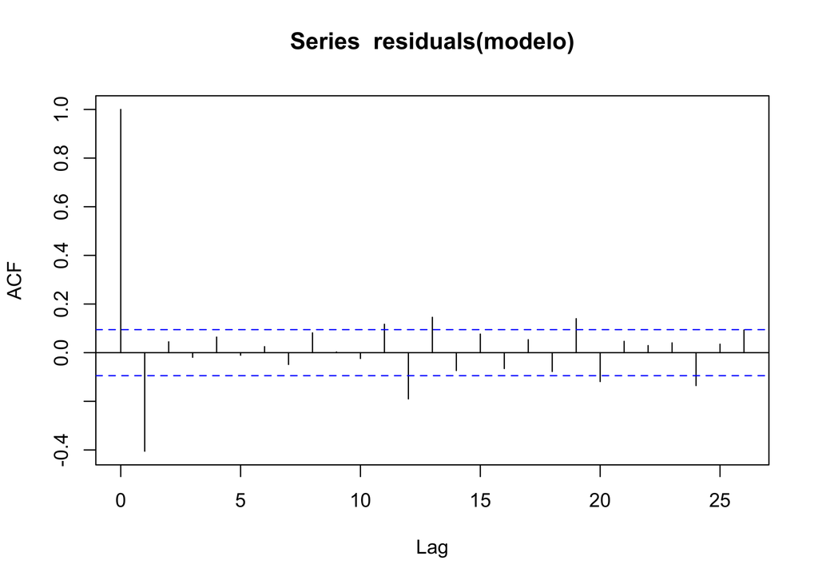

Função de autocorrelação amostral dos resíduos.

```r
# Exibe a FAC dos resíduos
# Na saída, fac$acf[2] corresponde à primeira defasagem, após a defasagem zero.
fac <- acf(residuals(modelo))
```

**DicaResposta**

A FAC mostra evidência visual clara de autocorrelação. Na primeira defasagem, a autocorrelação amostral é aproximadamente -0.405, portanto o padrão inicial é de **autocorrelação negativa**.

Para o teste de Breusch–Godfrey de primeira ordem, consideramos:

$$H_0:\rho_1=0
\qquad\text{contra}\qquad
H_1:\rho_1\neq0.$$

```r
# Testa a presença de autocorrelação de primeira ordem
resultado_bg <- lmtest::bgtest(modelo, order = 1)

# Exibe o resultado do teste
resultado_bg
```

```
    Breusch-Godfrey test for serial correlation of order up to 1

data:  modelo
LM test = 72.7, df = 1, p-value <0.0000000000000002
```

**DicaResposta**

A estatística do teste é 72.7, com um grau de liberdade e valor-*p* inferior a 0,001. Ao nível de 5%, rejeitamos $H_0$. Há evidência de autocorrelação de primeira ordem nos erros do modelo, coerente com o padrão observado na FAC dos resíduos.

### **c.** Calcule a inferência com erros-padrão de Newey–West e explique por que os coeficientes permanecem os mesmos, os erros-padrão podem mudar e essa correção é adequada ao diagnóstico.

```r
# Estima a matriz de covariância HAC de Newey-West
# Sem lag explícito, o número de defasagens é escolhido automaticamente.
vcov_nw <- sandwich::NeweyWest(
  modelo,
  prewhite = FALSE,
  # Corrige a matriz pelo tamanho da amostra e pelo número de parâmetros.
  adjust = TRUE
)

# Calcula a inferência com a matriz de covariância Newey-West
resultado_nw <- lmtest::coeftest(
  modelo,
  vcov. = vcov_nw
)

# Exibe os resultados da inferência Newey-West
broom::tidy(resultado_nw)
```

```
# A tibble: 4 × 5
  term          estimate std.error statistic  p.value
  <chr>            <dbl>     <dbl>     <dbl>    <dbl>
1 (Intercept)      -4.34      2.98    -1.46  0.146
2 diff_mr         -41.6      18.8     -2.21  0.0274
3 diff_industry    38.4       9.81     3.91  0.000106
4 diff_unemp       12.2      13.4      0.909 0.364
```

**DicaResposta**

Newey–West não reestima a regressão nem os coeficientes de MQO. As estimativas pontuais permanecem iguais porque apenas a matriz de covariância usada na inferência é substituída. Com essa nova matriz, podem mudar os erros-padrão, as estatísticas de teste, os valores-*p* e os intervalos de confiança.

Como `lag` não foi informado, `NeweyWest()` selecionou automaticamente **seis defasagens**, considerando as covariâncias até essa ordem no cálculo HAC. Já o teste de Breusch–Godfrey com `order = 1` investiga autocorrelação de primeira ordem. Portanto, a ordem do teste não determina o número de defasagens usado na estimação da matriz de covariância HAC.

A correção HAC de Newey–West permite inferência robusta à heterocedasticidade e à autocorrelação sob as condições tratadas na aula. Por isso, é apropriada diante da dependência temporal diagnosticada nos erros. Ela não implica que todos os erros-padrão necessariamente aumentarão.

### **d.** Compare a inferência convencional com a inferência obtida utilizando erros-padrão de Newey–West.

**Inferência convencional**

```r
# Obtém a inferência convencional
resultado_conv <- lmtest::coeftest(modelo)

# Apresenta a inferência convencional com intervalos de confiança de 95%
broom::tidy(resultado_conv, conf.int = TRUE)
```

```
# A tibble: 4 × 7
  term          estimate std.error statistic     p.value conf.low conf.high
  <chr>            <dbl>     <dbl>     <dbl>       <dbl>    <dbl>     <dbl>
1 (Intercept)      -4.34      4.63    -0.937 0.349          -13.5      4.77
2 diff_mr         -41.6      23.1     -1.80  0.0729         -87.1      3.87
3 diff_industry    38.4       7.36     5.22  0.000000287     23.9     52.9
4 diff_unemp       12.2      12.5      0.979 0.328          -12.3     36.7
```

**Inferência de Newey–West**

```r
# Apresenta a inferência HAC com intervalos de confiança de 95%
broom::tidy(resultado_nw, conf.int = TRUE)
```

```
# A tibble: 4 × 7
  term          estimate std.error statistic  p.value conf.low conf.high
  <chr>            <dbl>     <dbl>     <dbl>    <dbl>    <dbl>     <dbl>
1 (Intercept)      -4.34      2.98    -1.46  0.146       -10.2      1.52
2 diff_mr         -41.6      18.8     -2.21  0.0274      -78.5     -4.66
3 diff_industry    38.4       9.81     3.91  0.000106     19.1     57.7
4 diff_unemp       12.2      13.4      0.909 0.364       -14.2     38.6
```

**DicaResposta**

1. As estimativas dos coeficientes não mudam, pois Newey–West substitui apenas a matriz de covariância usada na inferência.
2. Os erros-padrão não mudam todos na mesma direção. Para `diff_mr`, o erro-padrão diminui de aproximadamente 23,14 para 18,80. Para `diff_industry`, aumenta de aproximadamente 7,36 para 9,81.
3. Os intervalos de confiança mudam porque a incerteza (os erros-padrão) passou a ser estimada com a matriz HAC. Para `diff_mr`, o intervalo convencional é aproximadamente $[-87,08;\ 3,87]$ e inclui zero, enquanto o intervalo Newey–West é aproximadamente $[-78,55;\ -4,66]$ e não inclui zero.
4. Com $\alpha=5\%$, a conclusão sobre `diff_mr` muda: a inferência convencional não rejeita $H_0:\beta_1=0$, mas a inferência Newey–West rejeita essa hipótese. `diff_industry` continua apresentando forte evidência estatística, mesmo com o aumento do erro-padrão, e `diff_unemp` continua sem evidência estatística ao nível de 5%.
5. Para `diff_mr`, o coeficiente estimado é aproximadamente $-41,60$. Assim, um aumento de um ponto percentual na variação mensal da taxa hipotecária está associado, *ceteris paribus*, a uma redução de cerca de 41,60 mil unidades na variação mensal das novas construções. Com Newey–West, o erro-padrão é aproximadamente 18,80, o intervalo de confiança de 95% vai de $-78,55$ a $-4,66$ e o valor-*p* é aproximadamente 0,027. O intervalo é amplo, mas permanece inteiramente negativo, fornecendo evidência de uma associação negativa ao nível de 5%; isso não identifica um efeito causal.